# Humanitarian Funding Flows Analysis

Donor Profile: France, Government of

Author

AI Generated Analysis based on [OCHA Finantial Tracking Service Data API](https://fts.unocha.org/). Beware of data limitations and potential hallucinations! Thanks for reporting any [issues here](https://github.com/Edouard-Legoupil/ftsAnalysis/issues/new) – View all Reports

## Executive Summary

The Government of France emerges as an evolving and increasingly pivotal humanitarian donor with a pronounced scaling-up of financial commitments. After a period of modest contributions through 2020–2022, France’s funding trajectory demonstrates a significant escalation starting in 2023, culminating in a projected nearly $380 million allocation by 2025. This trend signals a strategic intensification of humanitarian engagement and reflects France’s response to growing global crises and a potential policy reorientation toward crisis intervention and resilience strengthening.

France’s funding profile is characterized by a strong concentration both in earmarking and financial flow types. Over half of its humanitarian resources are allocated to a primary earmarking category, underlining a focused approach to addressing priority areas likely tied to urgent needs or strategic partnerships. This concentrated allocation pattern presents a critical consideration for humanitarian actors seeking alignment to optimize resource mobilization. Similarly, nearly all funding is channeled through one predominant flow type, suggesting a deliberate preference for streamlined, possibly bilateral or multilateral grant modalities which can enhance programmatic efficiency but may constrain flexibility.

Sectorally, France’s funding distribution is similarly targeted, with significant emphasis on a few key clusters receiving the majority of financial flows. While this focus supports impactful interventions within priority areas, it raises awareness around potential underfunding of smaller or emerging sectors that may be critical to comprehensive humanitarian responses.

For humanitarian fundraisers and program planners, France represents both a substantial opportunity and a challenge. The sheer scale-up in funding demands proactive engagement and readiness to absorb and deploy resources effectively. Success in securing French support will depend on strategic alignment with their prioritized sectors and funding channels. Additionally, there is scope for dialogue to advocate for more diversified funding across sectors and flow types to enhance flexibility and responsiveness. Overall, France stands as a donor poised for impactful leadership in global humanitarian financing in the coming years.

## Funding History

Over the past five years, funding from the Government of France for humanitarian activities has shown notable fluctuations with a significant surge on the horizon. Between 2020 and 2022, the financial support was relatively modest, peaking at just over six hundred thousand USD in 2020 before dropping drastically in 2022 to under ten thousand USD. However, starting in 2023, we observe a dramatic increase: funding jumped to over five and a half million USD and is projected to skyrocket to nearly 380 million USD by 2025. This pattern suggests a major strategic shift or an expanded humanitarian commitment. The sharp rise could reflect Frances response to escalating global humanitarian needs or new policies prioritizing crisis intervention and resilience building. For humanitarian partners, this signals a crucial opportunity to align with French funding priorities to maximize impact. Given this trajectory, it is essential for agencies to prepare to scale up operations and engage proactively with the French government to ensure that resources are deployed efficiently and reach the most vulnerable populations. In conclusion, Frances funding trends highlight an encouraging increase in humanitarian investment, presenting both a chance for enhanced response and a challenge to manage rapid growth effectively.

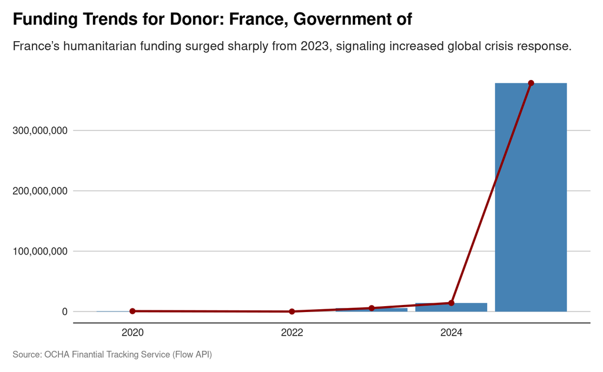

## Earmaking Approach

The Government of Frances humanitarian funding reveals a clear pattern in how resources are allocated across different earmarking types. A significant majority of funds, over 226 million USD, are directed toward one primary category, indicating a strong focus in their funding priorities. In comparison, other earmarking types receive substantially less support, ranging from approximately 55 to 59 million USD each. This disparity highlights Frances strategic choices in directing funds, possibly prioritizing areas with urgent needs or where France has established partnerships. For humanitarian responders and planners, this concentration signals the importance of aligning program proposals with Frances key funding channels to secure resources. Conversely, sectors receiving less earmarked funding may face challenges in accessing adequate support, underscoring potential gaps in financial coverage that could affect operational capacity or response effectiveness. To enhance impact, humanitarian coordination bodies might consider engaging with French donors to explore opportunities for more balanced allocation or increased flexibility. Understanding these funding patterns enables better anticipation of resource flows, facilitates targeted advocacy, and ultimately helps optimize the delivery of aid where it is most needed.

[figure not shown]

## Contribution Type

The analysis of France, Government ofs humanitarian funding reveals a striking concentration in one type of financial flow. The data shows two categories of flow types, where one category represents a modest amount of approximately 11,000 USD, while the other dominates with close to 400 million USD in funding. This vast difference highlights a clear prioritization in the allocation of resources. This distribution suggests that the majority of Frances humanitarian aid is channeled through a single flow type, indicating a focused approach to funding, possibly bilateral or multilateral grants, or direct project support. Such concentration can enhance the impact and efficiency of aid delivery, but it also raises questions about flexibility and responsiveness to diverse humanitarian needs across different contexts. For humanitarian executives, this pattern underscores the importance of understanding which flow type receives the bulk of funding and how it aligns with current global crises. It may prompt a review of whether funding diversity is sufficient to address varied operational challenges or if there is a need to encourage more balanced allocations. Ensuring that large funds are strategically targeted and monitored can maximize the effectiveness of Frances contributions to global humanitarian efforts.

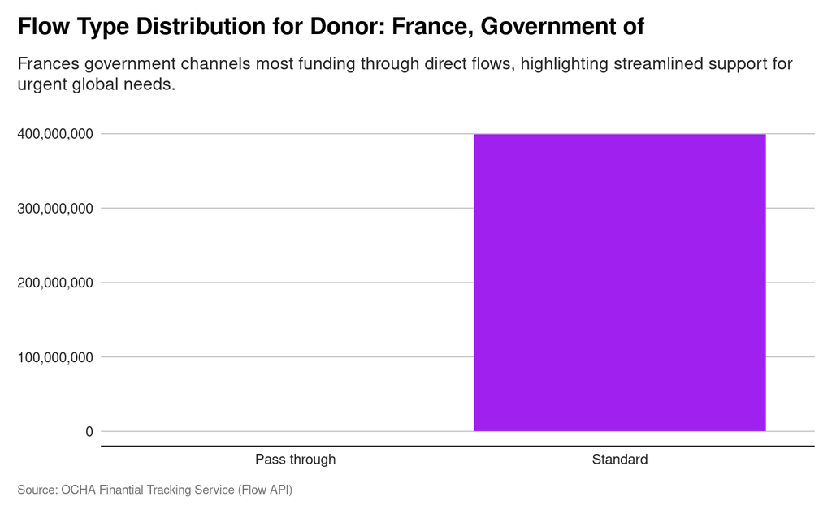

## Sectoral Prioritisation

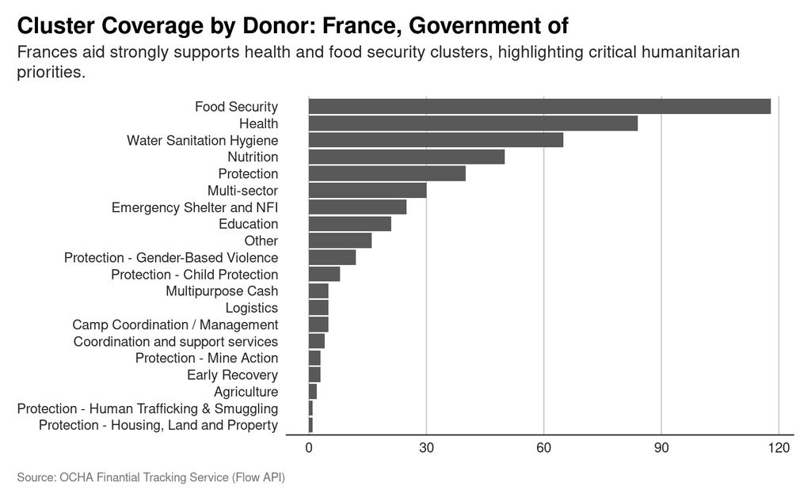